# HW1-DirectMarketing

Liping Li (lil112@pitt.edu)

2017.01.14

```r
# install.packages("data.table","ggplot2","gridExtra","caret","MASS","bestglm","glmnet","locfit"# )

library(data.table) # easy data manipulation
library(ggplot2) # nice plot
library(gridExtra) # sort plots
library(caret) # train models
library(glmnet) # lasso regularization
library(MASS) # stepwise
library(bestglm) # lm subset search
library(locfit)
```

```
## locfit 1.5-9.1    2013-03-22
```

## 1. Import Data

Use the dataset D2 described on p.294 in DMR

```r
data.file <- "http://www.yurulin.com/class/spring2017_datamining/data/DirectMarketing.csv"
D2 <- read.csv(data.file, header=T, sep=",")
# have header(column names), seperator is comma
dim(D2) # check number of rows and columns
```

```
## [1] 1000   10
```

1000 customers and 10 variables.

## 2. Explore Data

### 2.1 Identify and report response variable and predictors.

```r
str(D2)
```

```
## 'data.frame':    1000 obs. of  10 variables:
##  $ Age        : Factor w/ 3 levels "Middle","Old",..: 2 1 3 1 1 3 1 1 1 2 ...
##  $ Gender     : Factor w/ 2 levels "Female","Male": 1 2 1 2 1 2 1 2 1 2 ...
##  $ OwnHome    : Factor w/ 2 levels "Own","Rent": 1 2 2 1 1 1 2 1 1 1 ...
##  $ Married    : Factor w/ 2 levels "Married","Single": 2 2 2 1 2 1 2 2 1 1 ...
##  $ Location   : Factor w/ 2 levels "Close","Far": 2 1 1 1 1 1 1 1 1 2 ...
##  $ Salary     : int  47500 63600 13500 85600 68400 30400 48100 68400 51900 80700 ...
##  $ Children   : int  0 0 0 1 0 0 0 0 3 0 ...
##  $ History    : Factor w/ 3 levels "High","Low","Medium": 1 1 2 1 1 2 3 1 2 NA ...
##  $ Catalogs   : int  6 6 18 18 12 6 12 18 6 18 ...
##  $ AmountSpent: int  755 1318 296 2436 1304 495 782 1155 158 3034 ...
```

- Response variable:
  - AmountSpent (numeric; in dollars)
- Predictors:
  - Age (factor; 3 levels)
  - Gender (factor; Female/Male)
  - OwnHome (factor; Own/Rent)
  - Married (factor; Married/Single)
  - Location (factor; Close/Far; distance to the nearest brick and mortar store)
  - Salary (numeric; yearly salary of customer in dollars)
  - Children (number of children)
  - History (factor; 3 levels)
  - Catalogs (number of catalogs sent; customer receive catalogs and then order via mail)

Although Children and Catalogs are integers, they seem to have only several levels.

```r
D2 <- data.table(D2)
# upgrade data.frame to data.table.
# data.table inherits from data.frame therefore keeps data.frame properties.

print("Summary Children and Catalogs as numeric:")
```

```
## [1] "Summary Children and Catalogs as numeric:"
```

```r
summary(D2[,c("Children","Catalogs")])
```

```
##     Children        Catalogs
##  Min.   :0.000   Min.   : 6.00
##  1st Qu.:0.000   1st Qu.: 6.00
##  Median :1.000   Median :12.00
##  Mean   :0.934   Mean   :14.68
##  3rd Qu.:2.000   3rd Qu.:18.00
##  Max.   :3.000   Max.   :24.00
```

```r
D2 <- D2[,c("Children","Catalogs"):= lapply(.SD, as.factor), .SDcols = c("Children","Catalogs")] # change data type

print("Summary Children and Catalogs as factor:")
```

```
## [1] "Summary Children and Catalogs as factor:"
```

```r
summary(D2[,c("Children","Catalogs")])
```

```
##  Children Catalogs
##  0:462    6 :252
##  1:267    12:282
##  2:146    18:233
##  3:125    24:233
```

Children and Catalogs will be treated as factors(categorical variables) for their discrete distributions.

### 2.2 Summary table plus numerical variable summary list.

```r
summary(D2) # levels for factors &range for numeric
```

```
##      Age         Gender    OwnHome       Married     Location
##  Middle:508   Female:506   Own :516   Married:502   Close:710
##  Old   :205   Male  :494   Rent:484   Single :498   Far  :290
##  Young :287
##
##
##
##      Salary       Children   History    Catalogs  AmountSpent
##  Min.   : 10100   0:462    High  :255   6 :252   Min.   :  38.0
##  1st Qu.: 29975   1:267    Low   :230   12:282   1st Qu.: 488.2
##  Median : 53700   2:146    Medium:212   18:233   Median : 962.0
##  Mean   : 56104   3:125    NA's  :303   24:233   Mean   :1216.8
##  3rd Qu.: 77025                                  3rd Qu.:1688.5
##  Max.   :168800                                  Max.   :6217.0
```

Summary table is displayed above. It shows frequency of categorical variable levels and distribution information of numerical variables: min, 1st quantile, median, mean, 3rd quantile, and max. But **no standard deviation**.

Nearly half of them are female and the other half are male. For house owning condition, people who own a house are roughly as many as those who rent. Also, married people are roughly as many as singles.

People’s consumption history seems to be equally distribute in 4 levels: High, Medium, Low and NA’s, slightly more in NA’s.

Catalogs distribution also seems even, and slightly more in “6” and “12”.

Now let me construct the required **numerical summary list**:variable name, mean, median, 1st quartile, 3rd quartile, and standard deviation. Plusing min and max for complement.

```r
numeric.variable <- D2[ ,c("Salary","AmountSpent"),with=F]

sapply(numeric.variable, function(sl)
       list(mean=mean(sl), median=median(sl),
       min=min(sl), first.quartile=quantile(sl,probs = 0.25),
       third.quartile=quantile(sl, probs = 0.75), max=max(sl),
       standard.deviation=sd(sl)))
```

```
##                    Salary   AmountSpent
## mean               56103.9  1216.77
## median             53700    962
## min                10100    38
## first.quartile     29975    488.25
## third.quartile     77025    1688.5
## max                168800   6217
## standard.deviation 30616.31 961.0686
```

```r
rm(numeric.variable)
```

Finding mean is much greater than median, I suspect Salary and AmountSpent distributions are skewed to right.

### 2.3 Deal with History NA’s.

We can find 303 NA’s of History in summary table. But it cannot be treated as missing value. Because it means that this customer has not yet purchased anything. I think it’s better to be labeled as **None**.

```r
D2 <- D2[is.na(History), History := "None"] # overwrite NA's to None
summary(D2$History)
```

```
##   High    Low Medium   None
##    255    230    212    303
```

### 2.4 Numeric variable distribution.

Plot density for numerical variables AmountSpent and Salary.

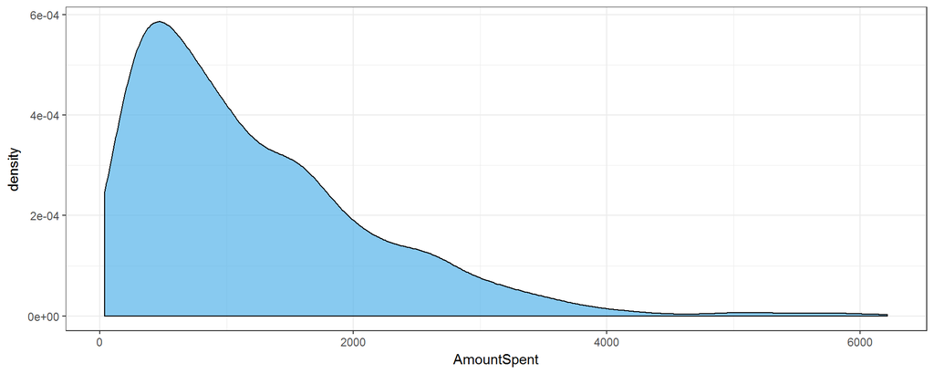

```r
theme_set(theme_bw()) # white background in plot
myPalette <- c("#56B4E9", "#009E73", "#E69F00", "#0072B2", "#D55E00", "#CC79A7")

p <- ggplot(D2, aes(x=AmountSpent))
p <- p + geom_density(alpha=0.7, fill="#56B4E9")
p
```

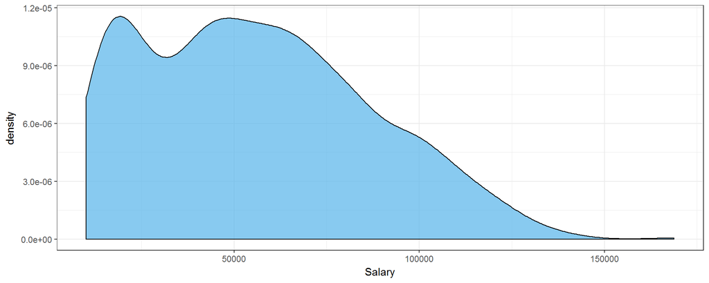

```r
p <- ggplot(D2, aes(x=Salary))
p <- p + geom_density(alpha=0.7, fill=myPalette[1])
p
```

Both AmountSpent and Salary are non-normal distributions and skewed to right.

Salary has two peaks.

Adds **normality test** information.

```r
shapiro.test(D2$AmountSpent)
```

```
##
##  Shapiro-Wilk normality test
##
## data:  D2$AmountSpent
## W = 0.8784, p-value < 2.2e-16
```

```r
shapiro.test(D2$Salary)
```

```
##
##  Shapiro-Wilk normality test
##
## data:  D2$Salary
## W = 0.96338, p-value = 3.763e-15
```

p-value is far more less than 0.05, demonstrating that we can reject the data is normally distributed.

### 2.5 Numeric variable correlationship.

Plot scatterplot for AmountSpent and Salary and examine their correlationship.

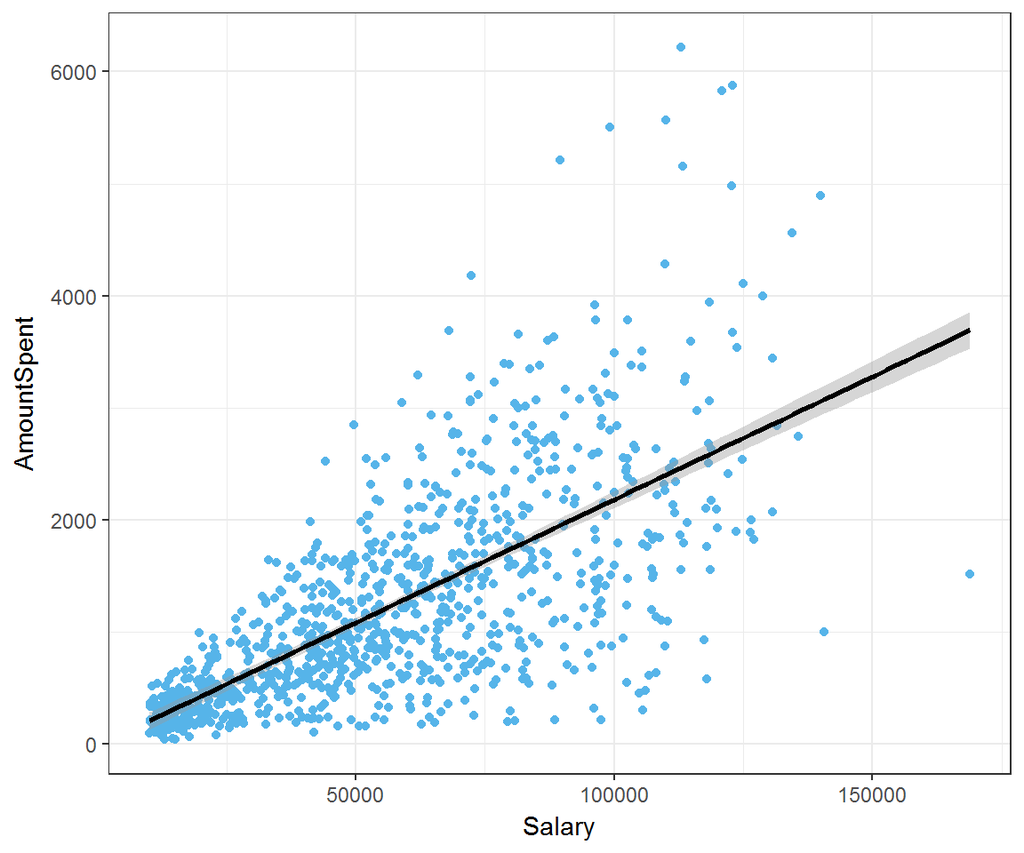

```r
p <- ggplot(D2, aes(x=Salary, y=AmountSpent))+geom_point(color=myPalette[1])
p <- p + geom_smooth(method="lm", color="black")
p
```

Salary and AmountSpent seems positively correlated, but variation at the right side are very big. Let’s test the correlation significance.

```r
cor.test(D2$Salary, D2$AmountSpent, method = "pearson")
```

```
##
##  Pearson's product-moment correlation
##
## data:  D2$Salary and D2$AmountSpent
## t = 30.93, df = 998, p-value < 2.2e-16
## alternative hypothesis: true correlation is not equal to 0
## 95 percent confidence interval:
##  0.6665092 0.7299316
## sample estimates:
##       cor
## 0.6995957
```

The coefficient is about 0.70, meaning increase in Salary is highly correlated with increase in AmountSpent. p < 0.001. This correlation between them is significant.

See how much this single variable explains.

```r
lm00 <- lm(AmountSpent~Salary, data=D2)
summary(lm00)
```

```
##
## Call:
## lm(formula = AmountSpent ~ Salary, data = D2)
##
## Residuals:
##     Min      1Q  Median      3Q     Max
## -2179.7  -315.2   -53.5   279.7  3752.9
##
## Coefficients:
##              Estimate Std. Error t value Pr(>|t|)
## (Intercept) -15.31783   45.37416  -0.338    0.736
## Salary        0.02196    0.00071  30.930   <2e-16 ***
## ---
## Signif. codes:  0 '***' 0.001 '**' 0.01 '*' 0.05 '.' 0.1 ' ' 1
##
## Residual standard error: 687.1 on 998 degrees of freedom
## Multiple R-squared:  0.4894, Adjusted R-squared:  0.4889
## F-statistic: 956.7 on 1 and 998 DF,  p-value: < 2.2e-16
```

### 2.5 Categorical variable X AmountSpent

For each categorical predictor, generate the conditional density plot of response variable

#### 2.5.1 Age X AmountSpent

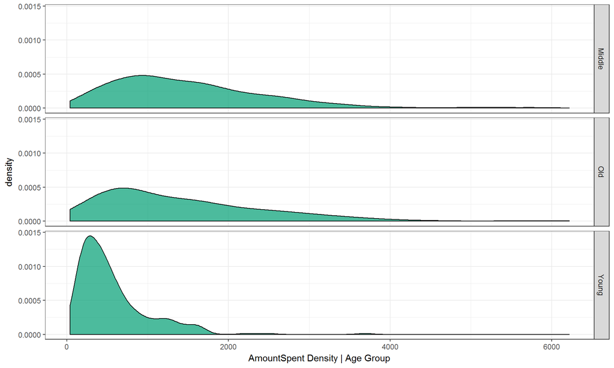

```r
p <- ggplot(D2, aes(x=AmountSpent))
p <- p + geom_density(alpha=0.7,fill=myPalette[2])
p <- p + facet_grid(Age ~.) + xlab("AmountSpent Density | Age Group")
p
```

AmountSpent distribtution on each Age group all seem to be skewed to right. Most Young people spent less than Middle &Old ones. Let’s see whether these differences are statistically significant.

```r
AgeLevel.mean <- D2[, list(mean=mean(AmountSpent),
                           standard.deviation=sd(AmountSpent)),by="Age"]
print(AgeLevel.mean)
```

```
##       Age      mean standard.deviation
## 1:    Old 1432.1268          1045.9300
## 2: Middle 1501.6909           959.2731
## 3:  Young  558.6237           450.1459
```

```r
Age.aov <- aov(AmountSpent~Age, data=D2)
summary(Age.aov)
```

```
##              Df    Sum Sq  Mean Sq F value Pr(>F)
## Age           2 175062951 87531475   116.7 <2e-16 ***
## Residuals   997 747666275   749916
## ---
## Signif. codes:  0 '***' 0.001 '**' 0.01 '*' 0.05 '.' 0.1 ' ' 1
```

```r
TukeyHSD(Age.aov)
```

```
##   Tukey multiple comparisons of means
##     95% family-wise confidence level
##
## Fit: aov(formula = AmountSpent ~ Age, data = D2)
##
## $Age
##                    diff       lwr        upr     p adj
## Old-Middle    -69.56412  -237.752   98.62377 0.5955085
## Young-Middle -943.06725 -1093.163 -792.97112 0.0000000
## Young-Old    -873.50314 -1059.379 -687.62710 0.0000000
```

Age grouped AmountSpent difference effect is significant(tested by ANOVA), and Young-Middle and Young-Old difference is confirmed by Tukey HSD test. Young group spent averagely 559 dollars, 943-dollar less than Middle Age group and 874-dollar less than Old Age group.

Store this module as a function for easy repeat on multi-level categorical factors.

```r
Cat.Amount.Mean <- function(dt,cat)
{
  CatLevel.mean <- dt[, list(mean=mean(AmountSpent),
                           standard.deviation=sd(AmountSpent)),by=cat]
  print(CatLevel.mean)

  Cat.aov <- aov(AmountSpent~cat, dt)
  print(summary(Cat.aov))
  print(TukeyHSD(Cat.aov))
}
```

#### 2.5.2 Gender X AmountSpent

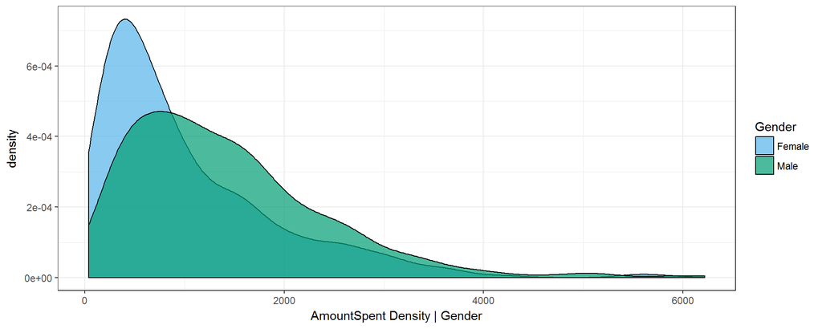

```r
p <- ggplot(D2, aes(x=AmountSpent, fill=Gender))
p <- p + geom_density(alpha=0.7)+scale_fill_manual(values=myPalette)
p <- p + xlab("AmountSpent Density | Gender")
p
```

Female tend to spend less than male. AmountSpent distribtution on each Gender group is also skewed to right. Since it’s a binary factor, I think t-test for the mean difference will work. Some references suggest t-test sample need to be normal distribution, where some say t-test is robust to non-normality (http://thestatsgeek.com/2013/09/28/the-t-test-and-robustness-to-non-normality/). Here I will go straight with t test.

```r
t.test(AmountSpent~Gender,data=D2)
```

```
##
##  Welch Two Sample t-test
##
## data:  AmountSpent by Gender
## t = -6.5002, df = 989.98, p-value = 1.27e-10
## alternative hypothesis: true difference in means is not equal to 0
## 95 percent confidence interval:
##  -504.4976 -270.5229
## sample estimates:
## mean in group Female   mean in group Male
##              1025.34              1412.85
```

Female’s average spent is 1025.34 dollars, 387.51 dollars less than Male’s. The probability of null hypothesis that the difference is equal to 0 is less than 0.01. Therefore, we consider this difference is not equal to 0.

#### 2.5.3 OwnHome X AmountSpent

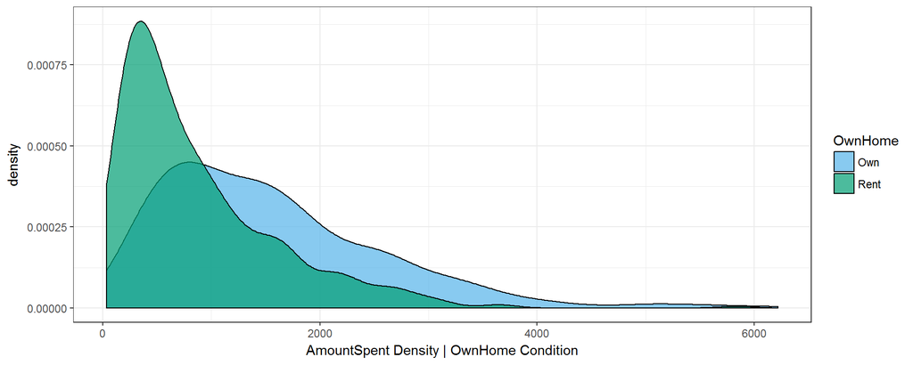

```r
p <- ggplot(D2, aes(x=AmountSpent, fill=OwnHome))
p <- p + geom_density(alpha=0.7)+scale_fill_manual(values=myPalette)
p <- p + xlab("AmountSpent Density | OwnHome Condition")
p
```

People who rent a house tend to spend less than those who own a house.

```r
t.test(AmountSpent~OwnHome,data=D2)
```

```
##
##  Welch Two Sample t-test
##
## data:  AmountSpent by OwnHome
## t = 11.957, df = 934.01, p-value < 2.2e-16
## alternative hypothesis: true difference in means is not equal to 0
## 95 percent confidence interval:
##  563.6391 784.9793
## sample estimates:
##  mean in group Own mean in group Rent
##          1543.1357           868.8264
```

#### 2.5.4 Married X AmountSpent

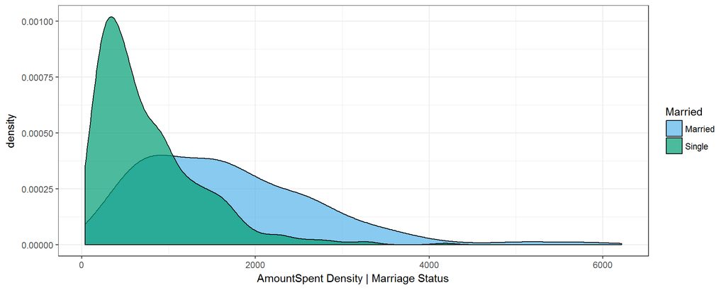

```r
p <- ggplot(D2, aes(x=AmountSpent, fill=Married))
p <- p + geom_density(alpha=0.7)+scale_fill_manual(values=myPalette)
p <- p + xlab("AmountSpent Density | Marriage Status")
p
```

People who are single tend to spend less than those who are married.

```r
t.test(AmountSpent~Married,data=D2)
```

```
##
##  Welch Two Sample t-test
##
## data:  AmountSpent by Married
## t = 17.128, df = 797.33, p-value < 2.2e-16
## alternative hypothesis: true difference in means is not equal to 0
## 95 percent confidence interval:
##   809.4786 1019.0343
## sample estimates:
## mean in group Married  mean in group Single
##             1672.0697              757.8133
```

People who are single spent 758 dollars averagely, 914-dollar less than those who are married. This difference is statistically significant.

#### 2.5.5 Location X AmountSpent

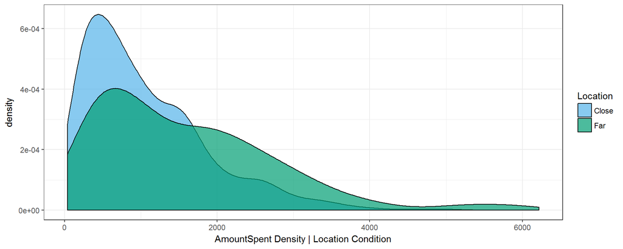

```r
p <- ggplot(D2, aes(x=AmountSpent, fill=Location))
p <- p + geom_density(alpha=0.7)+scale_fill_manual(values=myPalette)
p <- p + xlab("AmountSpent Density | Location Condition")
p
```

```r
t.test(AmountSpent~Location,data=D2)
```

```
##
##  Welch Two Sample t-test
##
## data:  AmountSpent by Location
## t = -7.0841, df = 404.96, p-value = 6.239e-12
## alternative hypothesis: true difference in means is not equal to 0
## 95 percent confidence interval:
##  -683.1713 -386.3741
## sample estimates:
## mean in group Close   mean in group Far
##            1061.686            1596.459
```

People who live far away from a store spent 1596 dollars averagely, 535-dollar more than those who live close to a local store. This difference is statistically significant.

#### 2.5.6 Children X AmountSpent

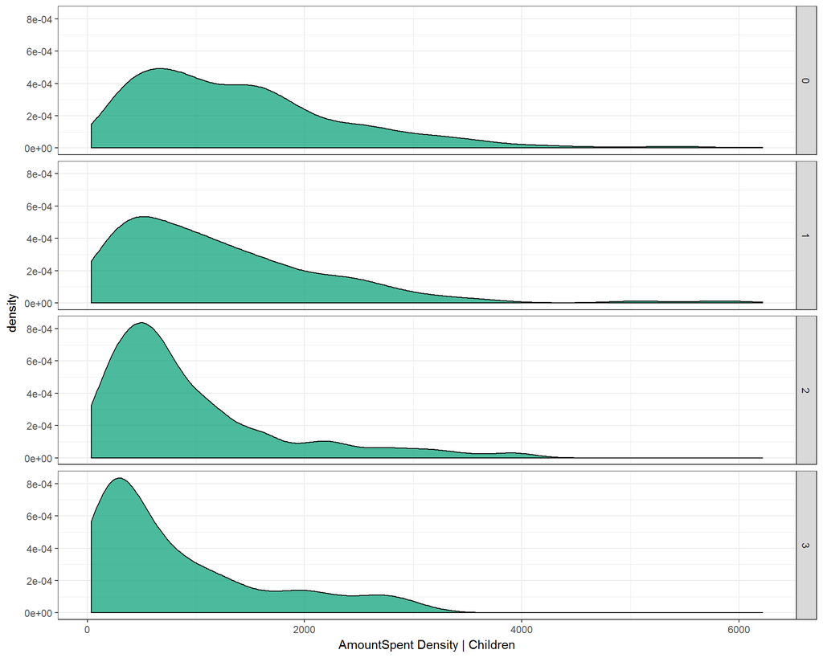

```r
p <- ggplot(D2, aes(x=AmountSpent))+facet_grid(Children~.)
p <- p + geom_density(alpha=0.7, fill=myPalette[2])
p <- p + xlab("AmountSpent Density | Children")
p
```

```r
Cat.Amount.Mean(D2,D2$Children)
```

```
##    cat      mean standard.deviation
## 1:   0 1406.6407           986.8434
## 2:   1 1219.5393           971.2940
## 3:   3  831.4880           795.3920
## 4:   2  940.7466           822.3071
##              Df    Sum Sq  Mean Sq F value   Pr(>F)
## cat           3  46336416 15445472   17.55 4.14e-11 ***
## Residuals   996 876392810   879912
## ---
## Signif. codes:  0 '***' 0.001 '**' 0.01 '*' 0.05 '.' 0.1 ' ' 1
##   Tukey multiple comparisons of means
##     95% family-wise confidence level
##
## Fit: aov(formula = AmountSpent ~ cat, data = dt)
##
## $cat
##          diff       lwr         upr     p adj
## 1-0 -187.1014 -372.6722   -1.530533 0.0472632
## 2-0 -465.8941 -695.0742 -236.713995 0.0000012
## 3-0 -575.1527 -818.5219 -331.783484 0.0000000
## 2-1 -278.7928 -527.2579  -30.327567 0.0206679
## 3-1 -388.0513 -649.6617 -126.440947 0.0008248
## 3-2 -109.2586 -403.4133  184.896119 0.7745238
```

More children people have, less they spent. Paired mean differences between people with 0, 1, 2, 3 are all significant except 2-3 pair.

#### 2.5.7 Consumption History X AmountSpent

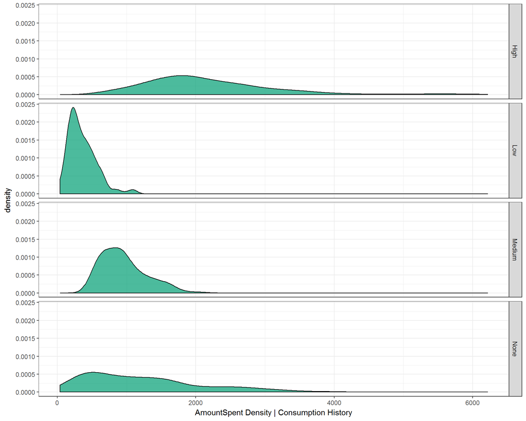

```r
p <- ggplot(D2, aes(x=AmountSpent))+facet_grid(History~.)
p <- p + geom_density(alpha=0.7, fill=myPalette[2])
p <- p + xlab("AmountSpent Density | Consumption History")
p
```

```r
Cat.Amount.Mean(D2,D2$History)
```

```
##       cat      mean standard.deviation
## 1:   High 2186.1373           971.6730
## 2:    Low  357.0870           203.4762
## 3: Medium  950.4009           327.1471
## 4:   None 1239.9010           865.1624
##              Df    Sum Sq   Mean Sq F value Pr(>F)
## cat           3 424803261 141601087   283.2 <2e-16 ***
## Residuals   996 497925964    499926
## ---
## Signif. codes:  0 '***' 0.001 '**' 0.01 '*' 0.05 '.' 0.1 ' ' 1
##   Tukey multiple comparisons of means
##     95% family-wise confidence level
##
## Fit: aov(formula = AmountSpent ~ cat, data = dt)
##
## $cat
##                   diff        lwr        upr    p adj
## Low-High    -1829.0503 -1994.5101 -1663.5905 0.00e+00
## Medium-High -1235.7363 -1404.8489 -1066.6237 0.00e+00
## None-High    -946.2363 -1100.8618  -791.6107 0.00e+00
## Medium-Low    593.3140   420.0793   766.5487 0.00e+00
## None-Low      882.8140   723.6907  1041.9374 0.00e+00
## None-Medium   289.5000   126.5817   452.4184 3.21e-05
```

People who bought higher volume before tend to spent more now. People who never bought things before have a moderate mean AmountSpent. Mean differences between groups are all significant.

#### 2.5.8 Catalogs X AmountSpent

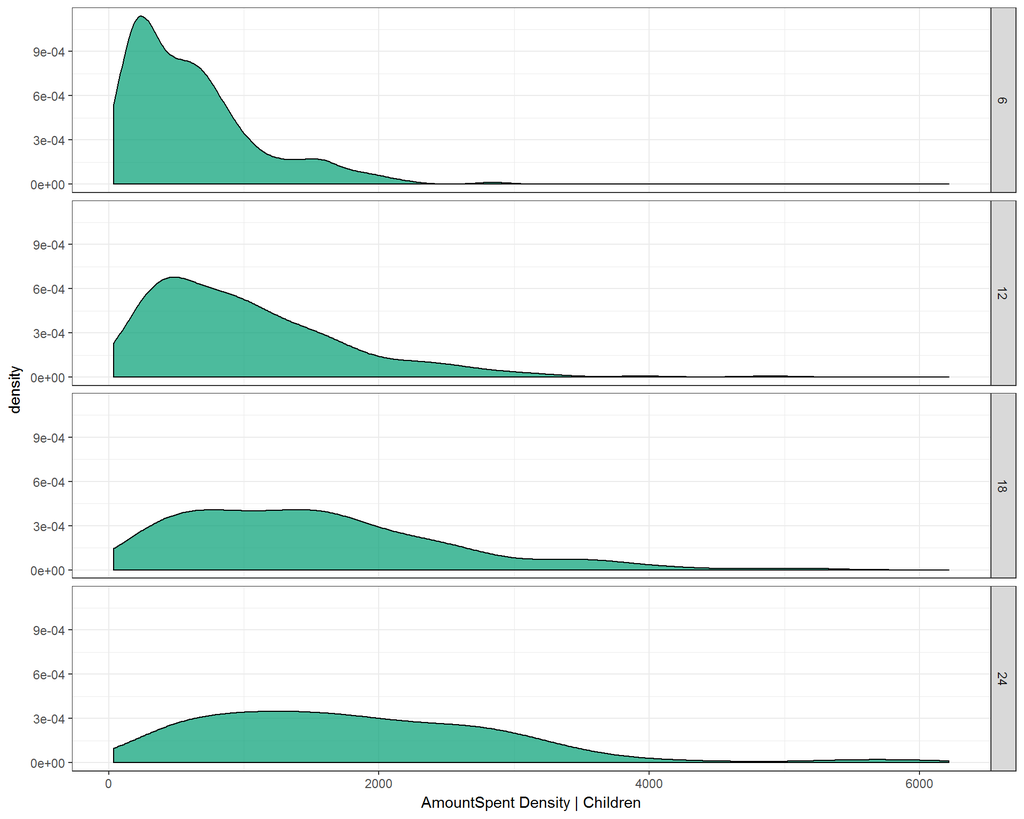

```r
p <- ggplot(D2, aes(x=AmountSpent))+facet_grid(Catalogs~.)
p <- p + geom_density(alpha=0.7, fill=myPalette[2])
p <- p + xlab("AmountSpent Density | Children")
p
```

```r
Cat.Amount.Mean(D2,D2$Catalogs)
```

```
##    cat      mean standard.deviation
## 1:   6  616.6746           478.3070
## 2:  18 1495.5451           964.0304
## 3:  12 1017.8546           725.2648
## 4:  24 1827.7725          1127.4173
##              Df    Sum Sq  Mean Sq F value Pr(>F)
## cat           3 206999072 68999691   96.02 <2e-16 ***
## Residuals   996 715730153   718605
## ---
## Signif. codes:  0 '***' 0.001 '**' 0.01 '*' 0.05 '.' 0.1 ' ' 1
##   Tukey multiple comparisons of means
##     95% family-wise confidence level
##
## Fit: aov(formula = AmountSpent ~ cat, data = dt)
##
## $cat
##            diff       lwr       upr     p adj
## 12-6   401.1800  212.0791  590.2809 0.0000004
## 18-6   878.8705  680.6080 1077.1329 0.0000000
## 24-6  1211.0979 1012.8355 1409.3604 0.0000000
## 18-12  477.6905  284.5608  670.8201 0.0000000
## 24-12  809.9179  616.7883 1003.0476 0.0000000
## 24-18  332.2275  130.1188  534.3361 0.0001496
```

More catalogs customers received, more dollars they spent. AmountSpent mean differences between people who received 6, 12, 18, 24 are all statistically significant.

### 2.6 Correlations between Indepent Variables

AmountSpent density plot pattern of binary variables are very similar. I plan to go over correlationships between independent variables.

```r
cat.variable <- data.frame(D2[ ,-c("Salary","AmountSpent"),with=F])

# I have a self-defined function for pairwise chi-square test
# https://github.com/dawn-llp/Functions/blob/master/MultiChi.R"
# Cannot use source() to load the url, but local file works.
# Copy the whole function code
chiMatrix = function(dt) # input a data frame or matrix
{
  n=ncol(dt)
  c=rep(1,(n*n))
  rec=matrix(c,n)

  for (i in 1:n)
  {
    for (j in i:n)
    {
      rec[i,j]=chisq.test(dt[,i],dt[,j])$p.value
      rec[j,i]=rec[i,j]
    }
  }
  colnames(rec)=colnames(dt)
  rownames(rec)=colnames(dt)
  return(rec)
}

pickChi=function(dt,p=0.01) # input a data frame or matrix and p-value level
{
  data=chiMatrix(dt)
  n=ncol(data)
  a=colnames(data)
  for (i in 1:(n-1))
  {
    for (j in (i+1):n)
    {
      if(data[i,j]>p)
        cat("Chi-square test [",a[i],", ",a[j],"] >",p,"\n")
    }
  }
#  return(data)
}

# list variable pairs that are independentt to each other at p=0.05
pickChi(cat.variable, p=0.05)
```

```
## Chi-square test [ Age ,  Location ] > 0.05
## Chi-square test [ Gender ,  Location ] > 0.05
## Chi-square test [ OwnHome ,  Location ] > 0.05
## Chi-square test [ Married ,  Location ] > 0.05
## Chi-square test [ Married ,  Children ] > 0.05
## Chi-square test [ Location ,  Children ] > 0.05
```

Only these 6 pair of variables are independent to each other.

Let’s examine a pair that suggested dependency by Chi-Square test, e.g. [Age, OwnHome]

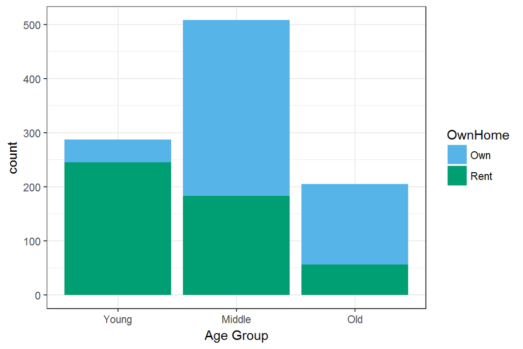

```r
positions <- c("Young","Middle","Old")
p <- ggplot(D2, aes(Age, fill=OwnHome))
p <- p + geom_bar()+scale_fill_manual(values=myPalette)
p <- p + scale_x_discrete(limits = positions) + xlab("Age Group")
p
```

Young people are more likely to rent a house rather than own.

How about Young people’s salary range? Does any categorical variable correlates with Salary?

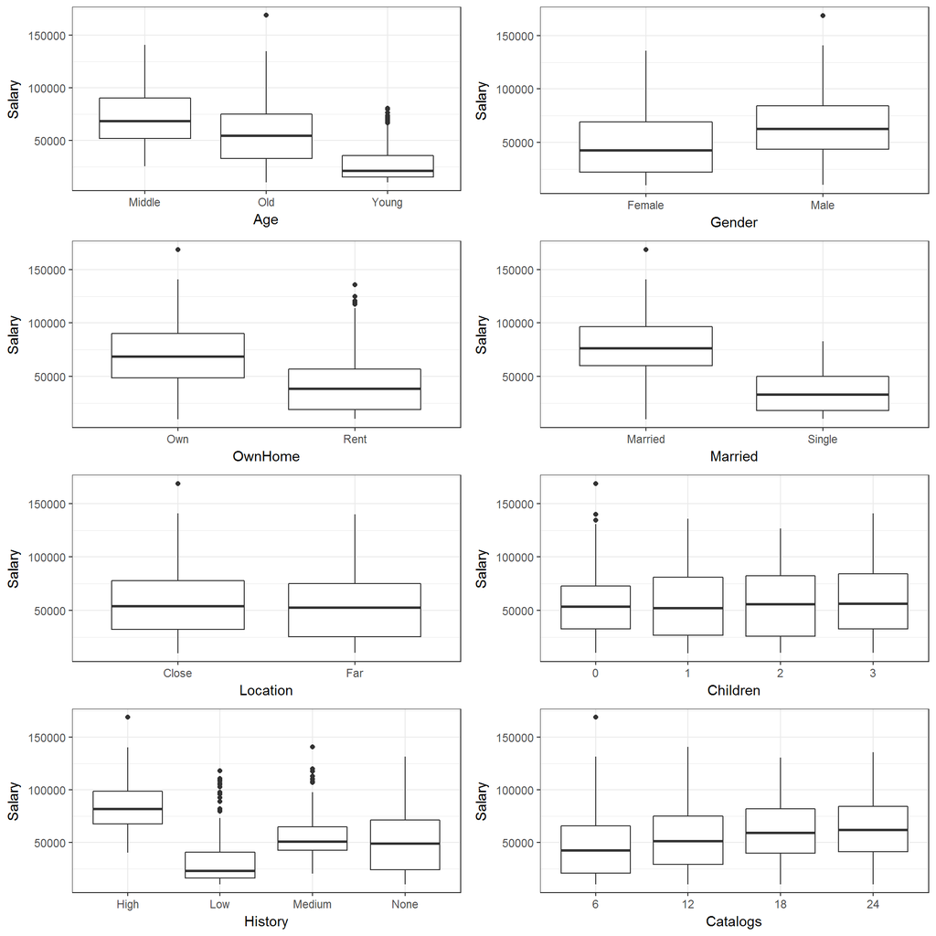

```r
p1 <- qplot(Age, Salary, data=D2, geom="boxplot")
p2 <- qplot(Gender, Salary, data=D2, geom="boxplot")
p3 <- qplot(OwnHome, Salary, data=D2, geom="boxplot")
p4 <- qplot(Married, Salary, data=D2, geom="boxplot")
p5 <- qplot(Location, Salary, data=D2, geom="boxplot")
p6 <- qplot(Children, Salary, data=D2, geom="boxplot")
p7 <- qplot(History, Salary, data=D2, geom="boxplot")
p8 <- qplot(Catalogs, Salary, data=D2, geom="boxplot")
grid.arrange(p1,p2,p3,p4,p5,p6,p7,p8, ncol=2)
```

Salary seems to be correlated with Age, Gender, OwnHome, Married, and History.

```r
cat.name=names(cat.variable)
D2 <- data.frame(D2)
y <- D2$Salary
for (i in cat.name)
{
  x <- D2[,i]
  lm.test <- aov(y~x)
  cat("Salary~",i)
  cat("......\n")
  print(summary(lm.test))
  cat("\n")
}
```

```
## Salary~ Age......
##              Df    Sum Sq   Mean Sq F value Pr(>F)
## x             2 3.603e+11 1.801e+11   311.7 <2e-16 ***
## Residuals   997 5.762e+11 5.779e+08
## ---
## Signif. codes:  0 '***' 0.001 '**' 0.01 '*' 0.05 '.' 0.1 ' ' 1
##
## Salary~ Gender......
##              Df    Sum Sq   Mean Sq F value Pr(>F)
## x             1 6.403e+10 6.403e+10   73.25 <2e-16 ***
## Residuals   998 8.724e+11 8.741e+08
## ---
## Signif. codes:  0 '***' 0.001 '**' 0.01 '*' 0.05 '.' 0.1 ' ' 1
##
## Salary~ OwnHome......
##              Df    Sum Sq   Mean Sq F value Pr(>F)
## x             1 1.988e+11 1.988e+11   268.9 <2e-16 ***
## Residuals   998 7.376e+11 7.391e+08
## ---
## Signif. codes:  0 '***' 0.001 '**' 0.01 '*' 0.05 '.' 0.1 ' ' 1
##
## Salary~ Married......
##              Df    Sum Sq   Mean Sq F value Pr(>F)
## x             1 4.275e+11 4.275e+11   838.2 <2e-16 ***
## Residuals   998 5.090e+11 5.100e+08
## ---
## Signif. codes:  0 '***' 0.001 '**' 0.01 '*' 0.05 '.' 0.1 ' ' 1
##
## Salary~ Location......
##              Df    Sum Sq   Mean Sq F value Pr(>F)
## x             1 1.291e+09 1.291e+09   1.378  0.241
## Residuals   998 9.351e+11 9.370e+08
##
## Salary~ Children......
##              Df    Sum Sq   Mean Sq F value Pr(>F)
## x             3 2.596e+09 865430136   0.923  0.429
## Residuals   996 9.338e+11 937575386
##
## Salary~ History......
##              Df    Sum Sq   Mean Sq F value Pr(>F)
## x             3 3.290e+11 1.097e+11   179.8 <2e-16 ***
## Residuals   996 6.074e+11 6.098e+08
## ---
## Signif. codes:  0 '***' 0.001 '**' 0.01 '*' 0.05 '.' 0.1 ' ' 1
##
## Salary~ Catalogs......
##              Df    Sum Sq   Mean Sq F value   Pr(>F)
## x             3 3.460e+10 1.153e+10   12.74 3.57e-08 ***
## Residuals   996 9.018e+11 9.054e+08
## ---
## Signif. codes:  0 '***' 0.001 '**' 0.01 '*' 0.05 '.' 0.1 ' ' 1
```

Anova test shows Salary has correlation with all catagorical variables except Location and Children.

In general, most independent variables are **correlated with each other**.

## 3. Regression Modeling

### 3.1 All Predictors Included Model

```r
model1 <- lm(AmountSpent~., data=D2)
summary(model1)
```

```
##
## Call:
## lm(formula = AmountSpent ~ ., data = D2)
##
## Residuals:
##      Min       1Q   Median       3Q      Max
## -1748.18  -287.54   -20.43   235.53  2862.34
##
## Coefficients:
##                 Estimate Std. Error t value Pr(>|t|)
## (Intercept)   -4.021e+01  1.133e+02  -0.355  0.72272
## AgeOld         7.865e+01  4.967e+01   1.583  0.11366
## AgeYoung       1.532e+01  4.987e+01   0.307  0.75870
## GenderMale    -4.181e+01  3.317e+01  -1.260  0.20788
## OwnHomeRent   -2.044e+01  3.674e+01  -0.557  0.57799
## MarriedSingle  3.856e+01  4.467e+01   0.863  0.38824
## LocationFar    4.354e+02  3.595e+01  12.113  < 2e-16 ***
## Salary         1.933e-02  1.034e-03  18.696  < 2e-16 ***
## Children1     -1.260e+02  4.227e+01  -2.981  0.00294 **
## Children2     -3.157e+02  5.222e+01  -6.046 2.11e-09 ***
## Children3     -4.915e+02  5.795e+01  -8.481  < 2e-16 ***
## HistoryLow    -3.489e+02  6.565e+01  -5.315 1.32e-07 ***
## HistoryMedium -3.954e+02  5.374e+01  -7.358 3.94e-13 ***
## HistoryNone    1.073e+01  5.151e+01   0.208  0.83507
## Catalogs12     1.888e+02  4.294e+01   4.398 1.21e-05 ***
## Catalogs18     4.858e+02  4.581e+01  10.604  < 2e-16 ***
## Catalogs24     7.398e+02  4.638e+01  15.951  < 2e-16 ***
## ---
## Signif. codes:  0 '***' 0.001 '**' 0.01 '*' 0.05 '.' 0.1 ' ' 1
##
## Residual standard error: 485.9 on 983 degrees of freedom
## Multiple R-squared:  0.7485, Adjusted R-squared:  0.7444
## F-statistic: 182.9 on 16 and 983 DF,  p-value: < 2.2e-16
```

```r
model1.rmse <- sqrt(mean((model1$residuals)^2))
cat("Model RMSE = ",model1.rmse)
```

```
## Model RMSE =  481.7248
```

When I apply standard linear regression on all predictors, the first level of catagorical variables is included in intercept. Overall, this model performs explains more than single Salary variable($ajusted-R^2 = 0.49$). $R^2 = 0.75$, $adjusted-R^2 = 0.74$, $RMSE = 481.72$.

In this model, Location level Far(compared with Close), Catalogs level 12, 18 and 24(compared with 6), and Salary are significantly positively correlated with more AmountSpent. And Children quantity 1, 2 and 3(compared with 0) and History consumption level Low and Medium(compared with High) are significantly negatively correlated with more AmountSpent. This result suggests **people who live far from a local store, have more salary, less children and high history consumption volume and recevie more catalogs are more likely to spend more money**.

What if I set Children and Catalogs back to numeric type?

```r
D2 <- data.table(D2)
D2 <- D2[,c("Children","Catalogs"):=lapply(.SD, as.character),.SDcols=c("Children","Catalogs")] # if change directly to numeric, level will start from 1

D2 <- D2[,c("Children","Catalogs"):=lapply(.SD, as.numeric), .SDcols=c("Children","Catalogs")]

summary(D2[,c("Children","Catalogs"),with=F])
```

```
##     Children        Catalogs
##  Min.   :0.000   Min.   : 6.00
##  1st Qu.:0.000   1st Qu.: 6.00
##  Median :1.000   Median :12.00
##  Mean   :0.934   Mean   :14.68
##  3rd Qu.:2.000   3rd Qu.:18.00
##  Max.   :3.000   Max.   :24.00
```

```r
model2 <- lm(AmountSpent~., data=D2)
summary(model2)
```

```
##
## Call:
## lm(formula = AmountSpent ~ ., data = D2)
##
## Residuals:
##      Min       1Q   Median       3Q      Max
## -1711.44  -292.41   -17.56   237.87  2876.91
##
## Coefficients:
##                 Estimate Std. Error t value Pr(>|t|)
## (Intercept)   -285.74892  116.39444  -2.455   0.0143 *
## AgeOld          63.36828   47.79586   1.326   0.1852
## AgeYoung         8.90120   49.70059   0.179   0.8579
## GenderMale     -46.99837   32.85192  -1.431   0.1529
## OwnHomeRent    -16.63382   36.64327  -0.454   0.6500
## MarriedSingle   32.74314   44.54067   0.735   0.4624
## LocationFar    436.50575   35.92138  12.152  < 2e-16 ***
## Salary           0.01920    0.00103  18.652  < 2e-16 ***
## Children      -162.73555   18.00348  -9.039  < 2e-16 ***
## HistoryLow    -352.89534   65.57529  -5.382 9.23e-08 ***
## HistoryMedium -404.41014   52.94420  -7.638 5.19e-14 ***
## HistoryNone      6.99218   51.32915   0.136   0.8917
## Catalogs        41.86880    2.45796  17.034  < 2e-16 ***
## ---
## Signif. codes:  0 '***' 0.001 '**' 0.01 '*' 0.05 '.' 0.1 ' ' 1
##
## Residual standard error: 485.7 on 987 degrees of freedom
## Multiple R-squared:  0.7476, Adjusted R-squared:  0.7446
## F-statistic: 243.7 on 12 and 987 DF,  p-value: < 2.2e-16
```

```r
model2.rmse <- sqrt(mean((model2$residuals)^2))
cat("Model RMSE = ",model2.rmse)
```

```
## Model RMSE =  482.5567
```

Result is similar. To simplify, I keep them as numeric variables now. Remove insignificant predictors, the equation will be

$AmountSpent = Location + Salary + Children + History + Catalogs$

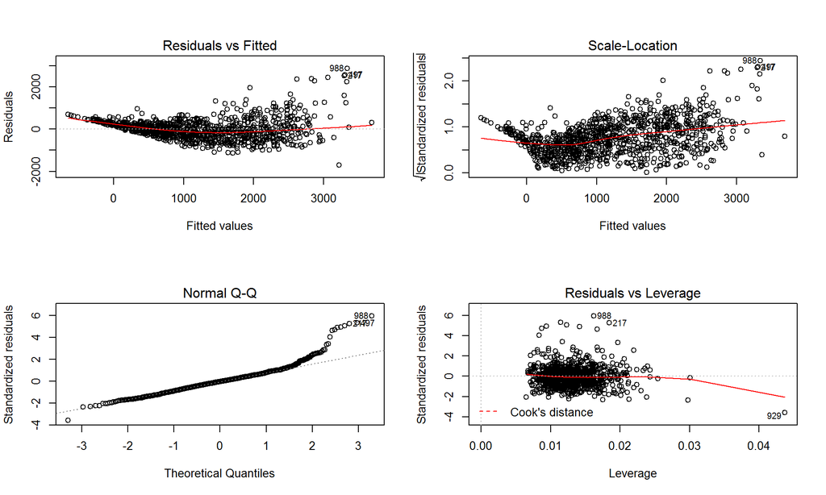

```r
layout(matrix(c(1,2,3,4),2,2)) # optional 4 graphs/page
plot(model2)
```

```r
shapiro.test(model2$residuals)
```

```
##
##  Shapiro-Wilk normality test
##
## data:  model2$residuals
## W = 0.9277, p-value < 2.2e-16
```

Residuals distribution is not normal too, failing to meet the normality requirement.

### 3.2 Predictor Combination Linear Model

#### 3.2.1 Predictor Search

I want to try different subsets of predictors in a cheap way.

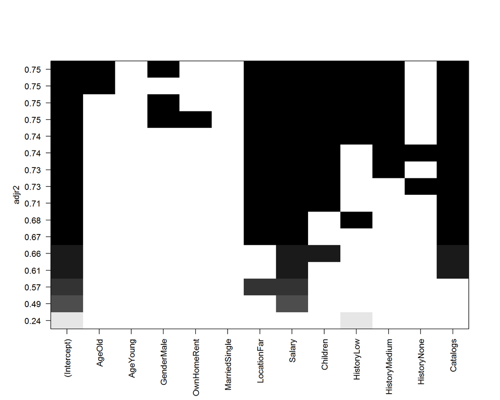

```r
combo1 <- regsubsets(AmountSpent~.,data=D2,nbest=2,method="exhaustive")
plot(combo1,scale="adjr2")
```

Trade-off adjusted R-square increase and predictor numbers, I think below can be consider candidates for the best one.

$AmountSpent = Age + Location + Salary + Children + History + Catalogs$

$AmountSpent = Gender + Location + Salary + Children + History + Catalogs$

$AmountSpent = Salary + Catalogs + location$

Plus a model built by variables that are relatively independent in previous correlation test.

$AmountSpent = Salary + Children + location$

Plus the result of full-predictior model

$AmountSpent = Location + Salary + Children + History + Catalogs$

#### 3.2.2 Compare RMSE of LOOCV training result of each models.

```r
train.control=trainControl(method="LOOCV")
cv.fit1 <- train(AmountSpent ~ Location + Salary + Children + History + Catalogs,
                 data=D2, trControl=train.control,method="lm")
cv.fit2 <- train(AmountSpent ~ Salary + Children + Location,
                 data=D2, trControl=train.control,method="lm")
cv.fit3 <- train(AmountSpent ~ Salary + Catalogs + Location,
                 data=D2, trControl=train.control,method="lm")
cv.fit4 <- train(AmountSpent ~ Gender + Location + Salary + Children + History + Catalogs,
                 data=D2, trControl=train.control,method="lm")
cv.fit5 <- train(AmountSpent ~ Age + Location + Salary + Children + History + Catalogs,
                 data=D2, trControl=train.control,method="lm")
print("Model 1: AmountSpent = Location + Salary + Children + History + Catalogs")
```

```
## [1] "Model 1: AmountSpent = Location + Salary + Children + History + Catalogs"
```

```r
print(cv.fit1$results)
```

```
##   intercept     RMSE  Rsquared
## 1      TRUE 488.3369 0.7415645
```

```r
print("Model 2: AmountSpent = Salary + Children + location")
```

```
## [1] "Model 2: AmountSpent = Salary + Children + location"
```

```r
print(cv.fit2$results)
```

```
##   intercept     RMSE  Rsquared
## 1      TRUE 584.1774 0.6301646
```

```r
print("Model 3: AmountSpent = Salary + Catalogs + location")
```

```
## [1] "Model 3: AmountSpent = Salary + Catalogs + location"
```

```r
print(cv.fit3$results)
```

```
##   intercept     RMSE  Rsquared
## 1      TRUE 557.7852 0.6628253
```

```r
print("Model 4: AmountSpent = Gender + Location + Salary + Children + History + Catalogs")
```

```
## [1] "Model 4: AmountSpent = Gender + Location + Salary + Children + History + Catalogs"
```

```r
print(cv.fit4$results)
```

```
##   intercept     RMSE  Rsquared
## 1      TRUE 488.1256 0.7417896
```

```r
print("Model 5: AmountSpent = Age + Location + Salary + Children + History + Catalogs")
```

```
## [1] "Model 5: AmountSpent = Age + Location + Salary + Children + History + Catalogs"
```

```r
print(cv.fit5$results)
```

```
##   intercept     RMSE  Rsquared
## 1      TRUE 488.5605 0.7413311
```

In terms of RMSE, Model 4 is the best $RMSE = 488.13$. It contains one more predictor the model 1. So what about full predictors model?

```r
cv.fit6 <- train(AmountSpent ~ .,
                 data=D2, trControl=train.control,method="lm")
print("Model 6: All predictors")
```

```
## [1] "Model 6: All predictors"
```

```r
print(cv.fit6$results)
```

```
##   intercept     RMSE  Rsquared
## 1      TRUE 489.3011 0.7405528
```

Adding more predictors won’t decrease **LOOCV RMSE**. I think **Model 4** is the best linear model.

#### 3.2.3 Confirm feature selection with Lasso regression.

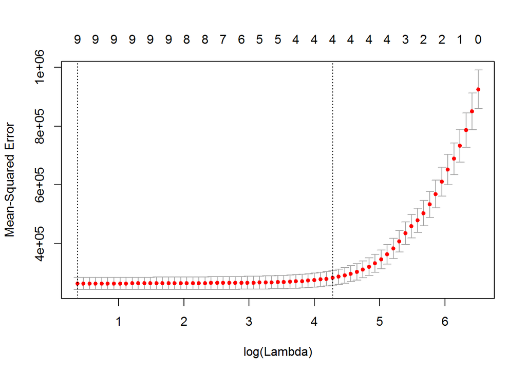

```r
x <- D2[,-10,with=F]
x <- x[ ,lapply(.SD, as.numeric)] # need to coerce to numeric for lasso
x <- as.matrix(x)
y <- as.matrix(D2[, 10,with=F])
cv.lasso=cv.glmnet(x,y,nfolds=1000)
plot(cv.lasso)
```

```r
coef(cv.lasso)
```

```
## 10 x 1 sparse Matrix of class "dgCMatrix"
##                         1
## (Intercept) -690.96755186
## Age            .
## Gender         .
## OwnHome        .
## Married        .
## Location     355.07828937
## Salary         0.01858993
## Children    -135.95197514
## History        .
## Catalogs      36.35048959
```

Lasso regularization suggests $AmountSpent = Location + Salary + Children + Catalogs$. Test again.

```r
cv.fit7 <- train(AmountSpent ~ Location + Salary + Children + Catalogs,
                 data=D2, trControl=train.control,method="lm")
print("Model 7: AmountSpent = Location + Salary + Children + Catalogs")
```

```
## [1] "Model 7: AmountSpent = Location + Salary + Children + Catalogs"
```

```r
print(cv.fit7$results)
```

```
##   intercept     RMSE  Rsquared
## 1      TRUE 516.2468 0.7111757
```

```r
rm(x,y)
```

Testing lm RMSE does not give a better result than Model 4. Since lasso test in glmnet package need all numeric variables, it might be inappropriate in this case.

### 3.3 Predictor Combination non-Linear Model

#### 3.3.1 Polynomial Regression

Only Salary is appropriate for this kind of transformation. Though I label Children and Catalogs as numbers, but they have only 4 levels, too few to be treated as continous variable.

```r
# lm00 is AmountSpent ~ Salary, adjusted R-square 0.49
lm01 <- lm(AmountSpent ~ poly(Salary, degree = 10), data = D2)
summary(lm01)
```

```
##
## Call:
## lm(formula = AmountSpent ~ poly(Salary, degree = 10), data = D2)
##
## Residuals:
##     Min      1Q  Median      3Q     Max
## -2083.4  -321.8   -51.1   285.9  3825.4
##
## Coefficients:
##                             Estimate Std. Error t value Pr(>|t|)
## (Intercept)                  1216.77      21.60  56.337   <2e-16 ***
## poly(Salary, degree = 10)1  21251.24     683.00  31.115   <2e-16 ***
## poly(Salary, degree = 10)2   -592.16     683.00  -0.867   0.3862
## poly(Salary, degree = 10)3   -818.63     683.00  -1.199   0.2310
## poly(Salary, degree = 10)4  -1240.19     683.00  -1.816   0.0697 .
## poly(Salary, degree = 10)5  -1719.64     683.00  -2.518   0.0120 *
## poly(Salary, degree = 10)6  -1127.71     683.00  -1.651   0.0990 .
## poly(Salary, degree = 10)7     75.28     683.00   0.110   0.9123
## poly(Salary, degree = 10)8   1381.49     683.00   2.023   0.0434 *
## poly(Salary, degree = 10)9   1024.79     683.00   1.500   0.1338
## poly(Salary, degree = 10)10    94.29     683.00   0.138   0.8902
## ---
## Signif. codes:  0 '***' 0.001 '**' 0.01 '*' 0.05 '.' 0.1 ' ' 1
##
## Residual standard error: 683 on 989 degrees of freedom
## Multiple R-squared:    0.5,  Adjusted R-squared:  0.495
## F-statistic:  98.9 on 10 and 989 DF,  p-value: < 2.2e-16
```

Slight increase in adjusted R square with significant (Salary)<sup>5</sup> and (Salary)<sup>8</sup> predictor. Let’s add it into the Model 4.

```r
lm02 <- lm(AmountSpent ~ Gender + Location + Salary + Children + History + Catalogs
           +I(Salary)^5+I(Salary)^8, data = D2)
summary(lm02)
```

```
##
## Call:
## lm(formula = AmountSpent ~ Gender + Location + Salary + Children +
##     History + Catalogs + I(Salary)^5 + I(Salary)^8, data = D2)
##
## Residuals:
##      Min       1Q   Median       3Q      Max
## -1649.78  -286.23   -16.99   241.88  2925.47
##
## Coefficients: (1 not defined because of singularities)
##                 Estimate Std. Error t value Pr(>|t|)
## (Intercept)   -2.284e+02  7.990e+01  -2.858  0.00435 **
## GenderMale    -5.428e+01  3.217e+01  -1.687  0.09186 .
## LocationFar    4.360e+02  3.586e+01  12.160  < 2e-16 ***
## Salary         1.892e-02  6.899e-04  27.425  < 2e-16 ***
## Children      -1.720e+02  1.670e+01 -10.299  < 2e-16 ***
## HistoryLow    -3.551e+02  6.543e+01  -5.427 7.21e-08 ***
## HistoryMedium -4.088e+02  5.237e+01  -7.807 1.49e-14 ***
## HistoryNone   -3.510e-02  5.106e+01  -0.001  0.99945
## Catalogs       4.175e+01  2.452e+00  17.029  < 2e-16 ***
## I(Salary)             NA         NA      NA       NA
## ---
## Signif. codes:  0 '***' 0.001 '**' 0.01 '*' 0.05 '.' 0.1 ' ' 1
##
## Residual standard error: 485.4 on 991 degrees of freedom
## Multiple R-squared:  0.7469, Adjusted R-squared:  0.7449
## F-statistic: 365.6 on 8 and 991 DF,  p-value: < 2.2e-16
```

The result shows a great probability of collinear.

#### 3.3.2 Validation script provided on the lecture page with ploy model of salary.

Rewrite some parts to smoothly run on my pc.

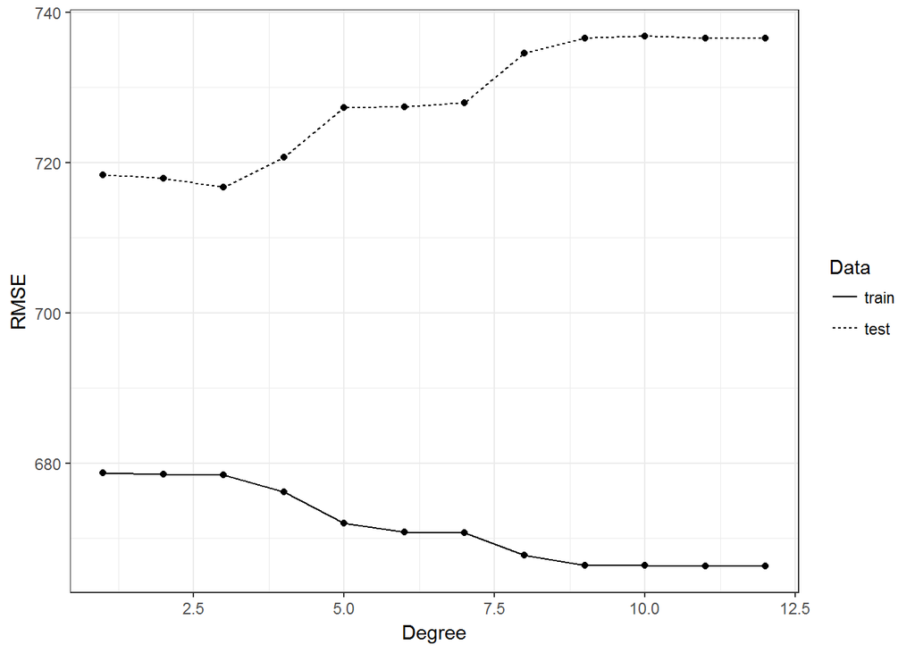

```r
## split our data into a training set and test set
x <- as.data.frame(D2[, 6,with=F])
y <- as.data.frame(D2[, 10,with=F])
n <- nrow(x) # change 1
set.seed(12345)
indices <- sample(n,round (0.8 * n)) # change 2
training.x <- x[indices,] # change 3
training.y <- y[indices,]
test.x <- x[-indices,]
test.y <- y[-indices,]
training.df <- data.frame(X = training.x, Y = training.y)
test.df <- data.frame(X = test.x, Y = test.y)
## use RMSE to measure the performance
rmse <- function(y, h) {
  return(sqrt(mean((y - h) ^ 2)))
}
## loop over a set of polynomial degrees (from 1 to 12)
performance <- data.frame()
for (d in 1:12)
{
  poly.fit <- lm(Y ~ poly(X, degree = d), data = training.df)
  performance <- rbind(performance ,
                       data.frame(Degree = d,
                                  Data = "train",
                                  RMSE = rmse(training.y,
                                              predict(poly.fit,                                                                                       newdata = training.df))))

  performance <- rbind(performance ,
                       data.frame(Degree = d,
                                  Data = "test",
                                  RMSE = rmse(test.y,
                                              predict(poly.fit ,
                                                      newdata = test.df))))
}
## plot the performance of the polynomial regression models for all the degrees
ggplot(performance , aes(x = Degree , y = RMSE , linetype = Data)) +
  geom_point() +
  geom_line()
```

#### 3.3.3 Local Polynomial Regression

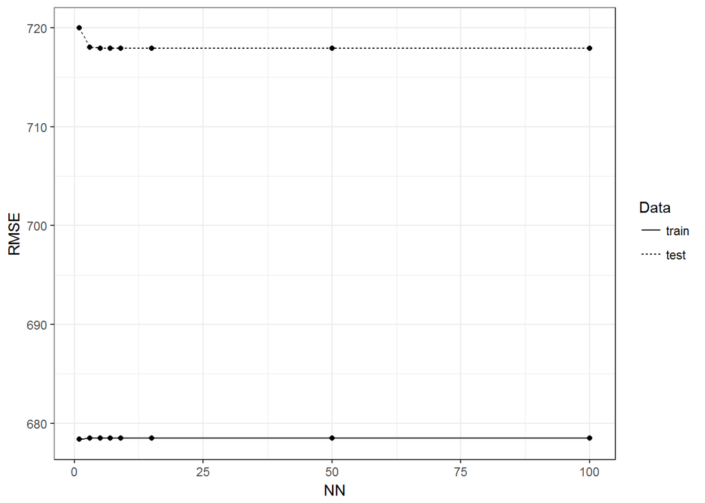

```r
## split our data into a training set and test set
set.seed(12345)
indices <- sample(n,round (0.8 * n))
training.x <- x[indices,]
training.y <- y[indices,]
test.x <- x[-indices,]
test.y <- y[-indices,]
training.df <- data.frame(X = training.x, Y = training.y)
test.df <- data.frame(X = test.x, Y = test.y)

## loop over a set of nn selections
performance <- data.frame()
nn.selection <- c(1,3,5,7,9,15,50,100)
for (n in nn.selection)
{
  loc.fit <- locfit(Y ~ lp(X, nn = n), data = training.df)
  performance <- rbind(performance ,
                       data.frame(NN = n,
                                  Data = "train",
                                  RMSE = rmse(training.y, predict(loc.fit,
                                                                  newdata = training.df))))

  performance <- rbind(performance ,
                       data.frame(NN = n,
                                  Data = "test",
                                  RMSE = rmse(test.y, predict(loc.fit ,
                                                              newdata = test.df))))
}
## plot the performance of the polynomial regression models for all the degrees
ggplot(performance , aes(x = NN , y = RMSE , linetype = Data)) +
  geom_point() +
  geom_line()
```

This method yeilds poor result.

### 3.4 Import Variables in Best Model

My best models is **Model 4: AmountSpent = Gender + Location + Salary + Children + History + Catalogs**

It’s partly supported by lasso regression result

$AmountSpent = Location + Salary + Children + Catalogs$

and subset search function.

#### 3.4.1 Plot variable importance.

Here I extract its variable importance.

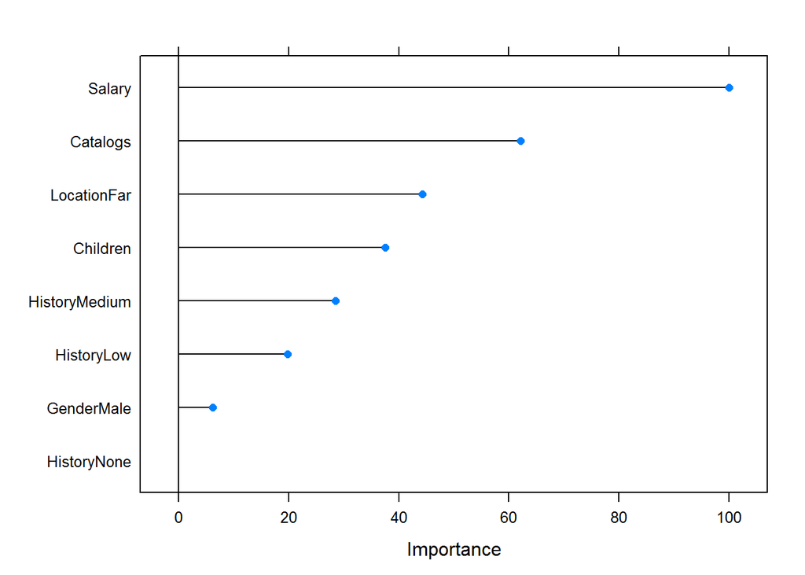

```r
plot(varImp(cv.fit4)) # importance%
```

#### 3.4.2 Examine this selection of variables by backward stepwise method.

```r
fit <- lm(AmountSpent ~ Salary + Catalogs + Location + Children + History + Gender,data=D2)
step <- stepAIC(fit, direction="backward")
```

```
## Start:  AIC=12379.03
## AmountSpent ~ Salary + Catalogs + Location + Children + History +
##     Gender
##
##            Df Sum of Sq       RSS   AIC
## <none>                  233522173 12379
## - Gender    1    670888 234193061 12380
## - Children  1  24994947 258517120 12479
## - History   3  29194376 262716549 12491
## - Location  1  34842146 268364319 12516
## - Catalogs  1  68330846 301853019 12634
## - Salary    1 177237435 410759607 12942
```

```r
step$anova # display results
```

```
## Stepwise Model Path
## Analysis of Deviance Table
##
## Initial Model:
## AmountSpent ~ Salary + Catalogs + Location + Children + History +
##     Gender
##
## Final Model:
## AmountSpent ~ Salary + Catalogs + Location + Children + History +
##     Gender
##
##
##   Step Df Deviance Resid. Df Resid. Dev      AIC
## 1                        991  233522173 12379.03
```

#### 3.4.3 Check RMSE change

```r
cv.var1 <- train(AmountSpent ~ Salary,
                 data=D2, trControl=train.control,method="lm")
cv.var2 <- train(AmountSpent ~ Salary + Catalogs,
                 data=D2, trControl=train.control,method="lm")
cv.var3 <- train(AmountSpent ~ Salary + Catalogs + Location,
                 data=D2, trControl=train.control,method="lm")
cv.var4 <- train(AmountSpent ~ Salary + Catalogs + Location + Children,
                 data=D2, trControl=train.control,method="lm")
cv.var5 <- train(AmountSpent ~ Salary + Catalogs + Location + Children + History,
                 data=D2, trControl=train.control,method="lm")
cv.var6 <- train(AmountSpent ~ Salary + Catalogs + Location + Children + History + Gender,
                 data=D2, trControl=train.control,method="lm")
print(cv.var1$results)
```

```
##   intercept     RMSE  Rsquared
## 1      TRUE 688.2645 0.4866273
```

```r
print(cv.var2$results)
```

```
##   intercept    RMSE  Rsquared
## 1      TRUE 600.622 0.6090474
```

```r
print(cv.var3$results)
```

```
##   intercept     RMSE  Rsquared
## 1      TRUE 557.7852 0.6628253
```

```r
print(cv.var4$results)
```

```
##   intercept     RMSE  Rsquared
## 1      TRUE 516.2468 0.7111757
```

```r
print(cv.var5$results)
```

```
##   intercept     RMSE  Rsquared
## 1      TRUE 488.3369 0.7415645
```

```r
print(cv.var6$results)
```

```
##   intercept     RMSE  Rsquared
## 1      TRUE 488.1256 0.7417896
```

Deleting Gender won’t influence LOOCV RMSE much.

## 4. Summary

Finally I decide to change my best model to:

**AmountSpent = Salary + Catalogs + Location + Children + History**. (Order presents importance)

Many relations among independent variables are not “independent”. Using all the predictiors and poly of salary all increase the risk of collinearity.

I think Salary + Catalogs + Location + Children + History is a reasonable combination. Salary reveals economic status and it’s correlated to other neglected factors like Gender, Age, OwnHome. Catalogs demonstrates how much ad information customers receive. Location show how far away a customer lives from a local store, independent of other factors. Children indicates family size, correlating with Age, OwnHome, etc. History indicates one’s consumption tendency, also correlating with other factors. Therefore, they together builds a linear model has small RMSE compared with using all the predictors.